# Lecture 2

## Data munging

- What are tidy data?
- Tidying data with *dplyr* and *tidyr*

### Introduction to Biostatistics

By: Peter Kamerman (view on GitHub)  
Based on the paper: Tidy Data by Hadley Wickam

### Why tidy data?

## The *tidy data* concept:

- Provides a standardized layout/organization for data values

## Standardization aids:

- Data exploration and analysis
- Data sharing
- The development of data cleaning and analysis tools

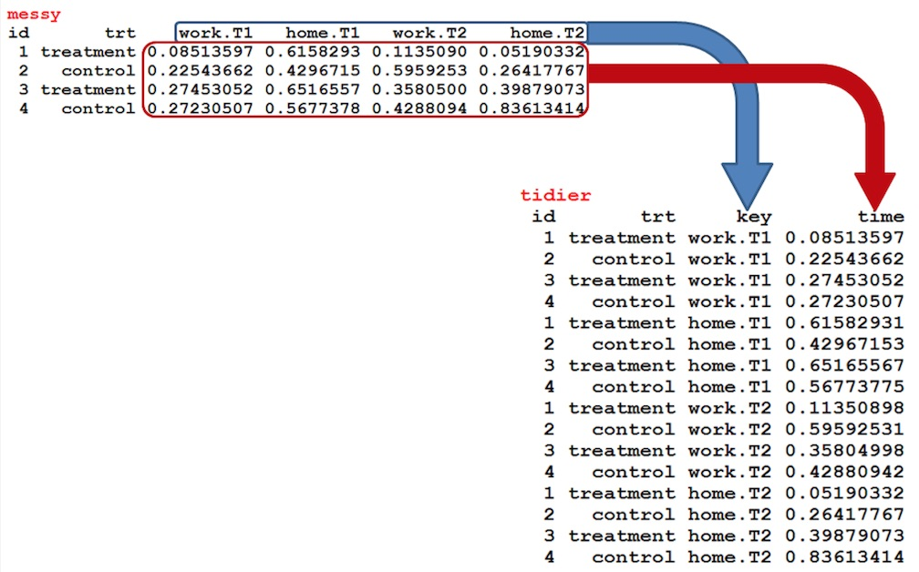

### Are my data messy?

[figure not shown]

But…data collected from laboratory experiments typically is collected and captured in a fairly structured format, making the job of tidying the data not too bad.

### Core principles of tidy data

## The language of datasets

- Datasets consist of **values** (usually numbers or strings)
- Every **value** belongs to a **variable** and an **observation**

## Structure of a *tidy dataset*

- **Variables** are arranged in **columns**
- **Observations** are arranged in **rows**
- Each type of observational unit forms a table

### Core principles of tidy data

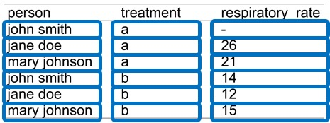

3 variables [A variable contains all values that measure the same underlying attribute (e.g., respiratory_rate, treatment)]

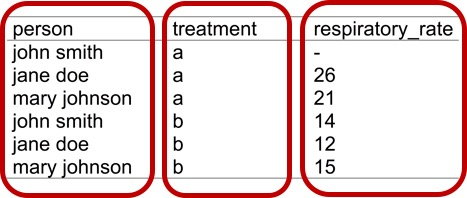

6 observations [An observation contains all values measured on the same unit across variables (e.g., person, or a day) ]

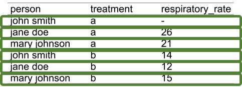

All contained in 1 table

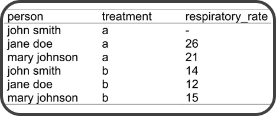

### Common causes of messiness

- Column headers are values, not variable names
- Multiple variables are stored in one column
- Variables are stored in both rows and columns
- Multiple types of experimental unit stored in the same table
- One type of experimental unit stored in multiple tables

### Common causes of messiness

**Column headers are values, not variables**

| religion | <$20k | >$20k |
| --- | --- | --- |
| Agnostic | 61 | 217 |
| Atheist | 39 | 124 |
| Buddhist | 48 | 97 |
| Catholic | 1035 | 2040 |

| religion | income | frequency |
| --- | --- | --- |
| Agnostic | <$20k | 61 |
| Agnostic | >$20k | 217 |
| Atheist | <$20k | 39 |
| Atheist | >$20k | 124 |
| Buddhist | <$20k | 48 |
| Buddhist | >$20k | 97 |
| Catholic | <$20k | 1035 |
| Catholic | >$20k | 2040 |

### Common causes of messiness

**Multiple variables stored in one column**

| country | year | sex_age | frequency |
| --- | --- | --- | --- |
| ZW | 2002 | m014 | 191 |
| ZW | 2002 | m1524 | 600 |
| ZW | 2002 | m2534 | 2548 |
| ZW | 2002 | m3544 | 1662 |

| country | year | frequency | sex | age_range |
| --- | --- | --- | --- | --- |
| ZW | 2002 | 191 | male | 0-14 |
| ZW | 2002 | 600 | male | 15-24 |
| ZW | 2002 | 2548 | male | 25-34 |
| ZW | 2002 | 1662 | male | 35-44 |

### Common causes of messiness

**Variables are stored in both rows and columns**

| site_id | year | month | element | d1 | d2 | d3 |
| --- | --- | --- | --- | --- | --- | --- |
| MX000017004 | 2010 | 11 | TMAX | 313 | 272 | 263 |
| MX000017004 | 2010 | 11 | TMIN | 163 | 120 | 79 |

| site_id | year | month | day | max_temp_F | min_temp_F |
| --- | --- | --- | --- | --- | --- |
| MX000017004 | 2010 | 11 | 1 | 313 | 163 |
| MX000017004 | 2010 | 11 | 2 | 272 | 120 |
| MX000017004 | 2010 | 11 | 3 | 263 | 79 |

### Common causes of messiness

| year | artist | track | time | week | rank | date |
| --- | --- | --- | --- | --- | --- | --- |
| 2000 | 2 Pac | Baby Don’t Cry | 04:22 | 1 | 87 | 26/02/2000 |
| 2000 | 2 Pac | Baby Don’t Cry | 04:22 | 2 | 82 | 04/03/2000 |
| 2000 | 2 Pac | Baby Don’t Cry | 04:22 | 3 | 72 | 11/03/2000 |
| 2000 | 2 Pac | Baby Don’t Cry | 04:22 | 4 | 77 | 18/03/2000 |
| 2000 | 2 Pac | Baby Don’t Cry | 04:22 | 5 | 87 | 25/03/2000 |
| 2000 | 2 Pac | Baby Don’t Cry | 04:22 | 6 | 94 | 01/04/2000 |

Split into song and rank information

### Common causes of messiness

Table 1: Song information

| artist | track | year | time |
| --- | --- | --- | --- |
| 2 Pac | Baby Don’t Cry | 2000 | 04:22 |
| 2Ge+her | The Hardest Part Of Breaking Up | 2000 | 03:15 |
| 3 Doors Down | Kryptonite | 2000 | 03:53 |

Table 2: Chart information

| artist | track | date | rank |
| --- | --- | --- | --- |
| 2 Pac | Baby Don’t Cry | 01/04/2000 | 94 |
| 2 Pac | Baby Don’t Cry | 04/03/2000 | 82 |
| 2 Pac | Baby Don’t Cry | 08/04/2000 | 99 |

### Common causes of messiness

**Single document type is stored in multiple tables**

Data values about a single type of observational unit may be spread out over multiple tables or files.

These tables and files are often split up by another variable (e.g., each table represents a single year, person, or location).

As long as the format for individual records is consistent, this is an easy problem to fix by merging tables.

### Tools to tidy and manipulate data

## The *grammer* of data cleaning

**Primary *tidyr* package verbs**

- `gather()`: gathers multiple columns into a key-value pair
- `spread()`: spreads two columns (key-value pair) in to multiple columns

### Tools to tidy and manipulate data

## The *grammer* of manipulating data

**Primary *dplyr* package verbs**

- `select()`: focus on a subset of variables (columns)
- `filter()`: focus on a subset of rows
- `mutate()`: add new columns
- `summarise()`: produce summary statistics of variables
- `arrange()`: re-order rows

### Examples: set-up

```r
# install required packages
install.packages(c('tidyr', 'dplyr'))

# load packages
library(tidyr) # to tidy data
library(dplyr) # to manipulate data
```

### Examples: tidyr

`gather()`: gathers multiple columns into a key-value pair

```r
# check documentation
?gather()

# use a sample of the 'iris' dataset
mini_iris <- iris[c(1, 51, 101), ]

# gather flower attributes:
gathered <- gather(data = mini_iris,
                   key = flower_attr,
                   value = measurement_mm,
                   Sepal.Length, Sepal.Width,
                   Petal.Length, Petal.Width)

# inspect and compare 'mini_iris'
# and 'gathered'
```

### Examples: tidyr

`spread()`: spreads two columns (key-value pair) in to multiple

```r
# check documentation
?spread()

# spread is the reverse of `gather()`
spreading <- spread(data = gathered,
                    key = flower_attr,
                    value = measurement_mm)

# inspect and compare 'mini_iris', 'gathered',
# and 'spreading'
```

### Examples: dplyr

`select()`: focus on a subset of variables (columns)

```r
# check documentation (note special functions)
?select()

# try some options on the 'iris' dataset
select(iris, Petal.Length, Petal.Width)
select(iris, starts_with("Petal"))
select(iris, ends_with("Width"))
select(iris, contains("etal"))
select(iris, matches(".t."))
select(iris, Petal.Length, Petal.Width)
vars <- c("Petal.Length", "Species")
select(iris, one_of(vars))

# redo examples, but put '-' before
# the variables
```

### Examples: dplyr

`filter()`: focus on a subset of rows using relational and logical operators

```r
# check documentation (note special functions)
?filter()

# try some filters on the 'mtcars' dataset
filter(mtcars, cyl == 8) # '==': EQUAL TO
filter(mtcars, cyl < 6) # '<': LESS THAN
filter(mtcars, cyl < 6 & vs == 1) # '&': AND
filter(mtcars, cyl < 6, vs == 1) # SAME AS '&'
filter(mtcars, cyl < 6 | vs == 1) # '|': OR
```

### Examples: dplyr

`mutate()`: add new columns

```r
# check documentation
?mutate()

# using 'mtcars' dataset
# add a new column with displacement in litres
mutate(mtcars,
       displ_l = disp / 61.0237)

# transmute adds column, dropping all others
transmute(mtcars,
          displ_l = disp / 61.0237)
```

### Examples: dplyr

`summarise()`: produce summary statistics of variables

```r
# check documentation
?summarise()

# use summary functions on 'mtcars' dataset
summarise(mtcars,
          mean(disp))

# use with 'group_by'
summarise(group_by(mtcars, cyl),
          mean(disp))

# get multiple summary stats
summarise(group_by(mtcars, cyl),
          m = mean(disp),
          sd = sd(disp))
```

### Examples: dplyr

`arrange()`: re-order rows

```r
# check documentation
?arrange()

# arrange 'mtcars' dataset
# default is ascending order
arrange(mtcars, cyl)

# use 'desc' to reverse the default
arrange(mtcars, desc(disp))

# arrange by multiple variables
arrange(mtcars, cyl, desc(disp))
```

### Examples: Piping ('%>%')

Piping (`%>%`) functionality:

- Is automatically imported into *dplyr* and *tidyr* from the *magrittr* package
- Allows the output from one command to be fed into the next.
- *'Unclutters'* long commands

```r
# using '%>%' on the 'mtcars' dataset
# pass final result to 'by_cyl'
by_cyl <- mtcars %>%
    group_by(cyl) %>%
    summarise(a = n(), b = a + 1) %>%
    arrange(a)
by_cyl
```

### Assignment

Complete *swirl* course: ‘Getting and Cleaning Data’

### Web resources

## Tidy data

- Wickham H. Tidy data. *J Stat Softw* **59**: 1-23, 2014. DOI: 10.18637/jss.v059.i10
- Tidy data vignette

## *dplyr* and *tidyr* packages

- [Introduction to *dplyr*](https://cran.rstudio.com/web/packages/dplyr/vignettes/introduction.html)
- Introduction to *tidyr*
- *dplyr* and *tidyr* cheat-sheet

### tl;dr

“Data that is loved tends to survive.”

Kurt Bollacker  
(Data Scientist, Freebase/Infochimps)